# Lab 5 – Inference for Categorical Data

## Lab Report Template

Your reproducible lab report: Before you get started, download the R Markdown template for this lab. Remember all of your code and answers go in this document:

```r
download.file("https://jacobfhsmith.github.io/STA101LFall2020/sta101_lab5.Rmd", destfile="sta101_lab5.Rmd")
```

In August of 2012, news outlets ranging from the [Washington Post](http://www.washingtonpost.com/national/on-faith/poll-shows-atheism-on-the-rise-in-the-us/2012/08/13/90020fd6-e57d-11e1-9739-eef99c5fb285_story.html) to the [Huffington Post](http://www.huffingtonpost.com/2012/08/14/atheism-rise-religiosity-decline-in-america_n_1777031.html) ran a story about the rise of atheism in America. The source for the story was a poll that asked people, “Irrespective of whether you attend a place of worship or not, would you say you are a religious person, not a religious person or a convinced atheist?” This type of question, which asks people to classify themselves in one way or another, is common in polling and generates categorical data. In this lab we take a look at the atheism survey and explore what’s at play when making inference about population proportions using categorical data.

## Set seed

Since we’ll be using the `sample` function in this lab, which involves randomness, we set a seed at the beginning of out document for reproducibility.

### Set seed:

```r
# Insert code for setting seed in this code chunk

# You may also wish to keep setting this same seed in code chunks going forward for ease
```

## Load packages

In this lab, we will explore and visualize the data using the **tidyverse** suite of packages. We’ll also use the **statsr** package for inference. Let’s load the packages. Note that if running `library(statsr)` gives you a message saying `Error in library(statsr) : there is no package called ‘statsr’` saying , then run `install.packages('statsr')` in your console.

```r
library(tidyverse)
library(statsr)
```

## The survey

To access the press release for the poll, conducted by WIN-Gallup International, click on the following link:

*https://sidmennt.is/wp-content/uploads/Gallup-International-um-tr%C3%BA-og-tr%C3%BAleysi-2012.pdf*

Take a moment to review the report and its methodology before moving on.

#### Exercise 1 (10 points)

**Look at Table 1 on page 9 of the report. What is the most religious country according to the 2012 survey? Is this value of religiosity most likely a sample statistic (derived from a data sample) or a population parameter?**

Now, turn your attention to Table 6 on pages 14 and 15 of the report.

#### Exercise 2 (10 points)

**How many people were sampled in Ghana in 2012? Which other country has the closest 2012 sample size to Ghana?**

## The Data

Having now seen this summary of the data, we’ll now look at the individual responses to this survey. Load the data with this command:

```r
load(url("http://www.openintro.org/stat/data/atheism.RData"))
```

Let’s consider the data for France, both as a nod to the origin of the “Blue Devils” nickname and because they had the largest increase in atheism listed in Table 4 of the report. Table 4 shows that France had an estimated 14% of individuals identifying as atheist in 2005 and an estimated 29% of individuals identifying as atheist in 2012.

#### Exercise 3 (5 points)

**Using the command below, create a new dataframe called `france12` that contains only the rows in `atheism` associated with respondents to the 2012 survey in France. Next, calculate the proportion of atheist responses. Does it agree with the percentage in Table 4?**

```r
# create a new dataframe (france12)
france12 <- atheism %>%
  filter(nationality == "France" & year == "2012")
# calculate the proportion of atheists
france12 %>%
  summarize(prop_atheist = mean(response=='atheist'))
```

## Inference on proportions

Table 6 in the report provides *statistics*, which are calculated from the sample of 51,927 people taken in 2012. Our goal in taking these samples and calculating associated statistics is to get an idea of what the population *parameters* are. You answer the question, “What proportion of people in your sample reported being atheists?” with a statistic; the question “What proportion of people on earth would report being atheists” is answered with a parameter, or in the absence of knowing that exactly, an estimate of that parameter.

The inferential tools for estimating population proportion are: the confidence interval and the hypothesis test.

#### Exercise 4 (15 points)

**Write out the conditions for inference to construct a 95% confidence interval for the proportion of atheists in France in 2012. Are you confident all conditions are met?**

If the conditions for inference are reasonable, we can calculate the standard error and construct the interval. You can do this by hand, but here in lab, we’ll allow the `inference` function to do it for us.

```r
statsr::inference(data = france12, y = response, success = "atheist",
                  statistic = "proportion", type = "ci", method = "theoretical")
```

```
## Single categorical variable, success: atheist
## n = 1688, p-hat = 0.2873
## 95% CI: (0.2657 , 0.3089)
```

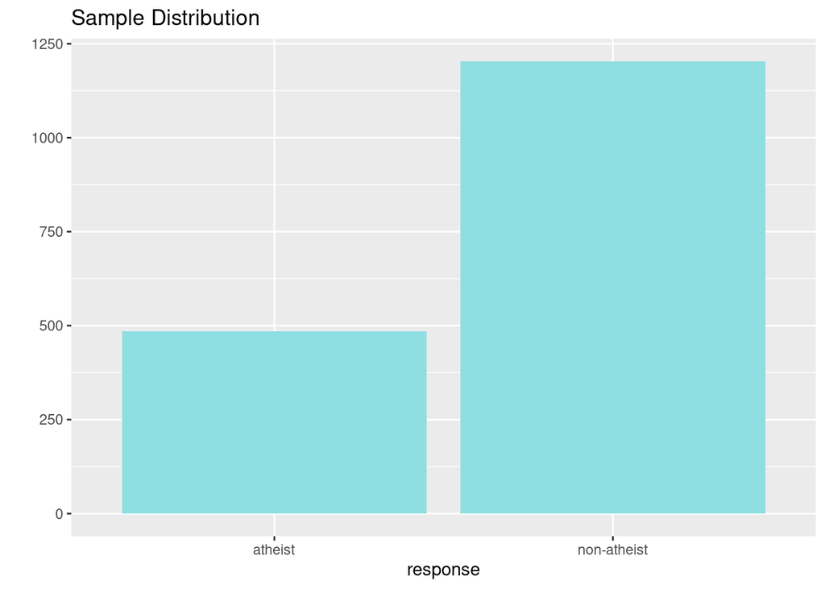

Note that since the goal is to construct an interval estimate for a proportion, it’s necessary to specify what constitutes a “success”, which here is a response of `"atheist"`.

Although formal confidence intervals and hypothesis tests don’t show up in the report, suggestions of inference appear at the bottom of page 6: “In general, the error margin for surveys of this kind is $\pm$ 3-5% at 95% confidence”.

#### Exercise 5 (10 points)

**Based on the R output, what is the margin of error for the estimate of the proportion of atheists in France in 2012?**

## Success-failure condition

The textbook emphasizes that you must always check conditions before making inference. For inference on proportions, the sample proportion can be assumed to be nearly normal if it is based upon a random sample of independent observations and if both $np \geq 10$ and $n(1 - p) \geq 10$. This rule of thumb is easy enough to follow, but it makes one wonder: what’s so special about the number 10?

The short answer is: nothing. You could argue that we would be fine with 9 or that we really should be using 11. What is the “best” value for such a rule of thumb is, at least to some degree, arbitrary. However, when $np$ and $n(1-p)$ reaches 10 the sampling distribution is sufficiently normal to use confidence intervals and hypothesis tests that are based on that approximation.

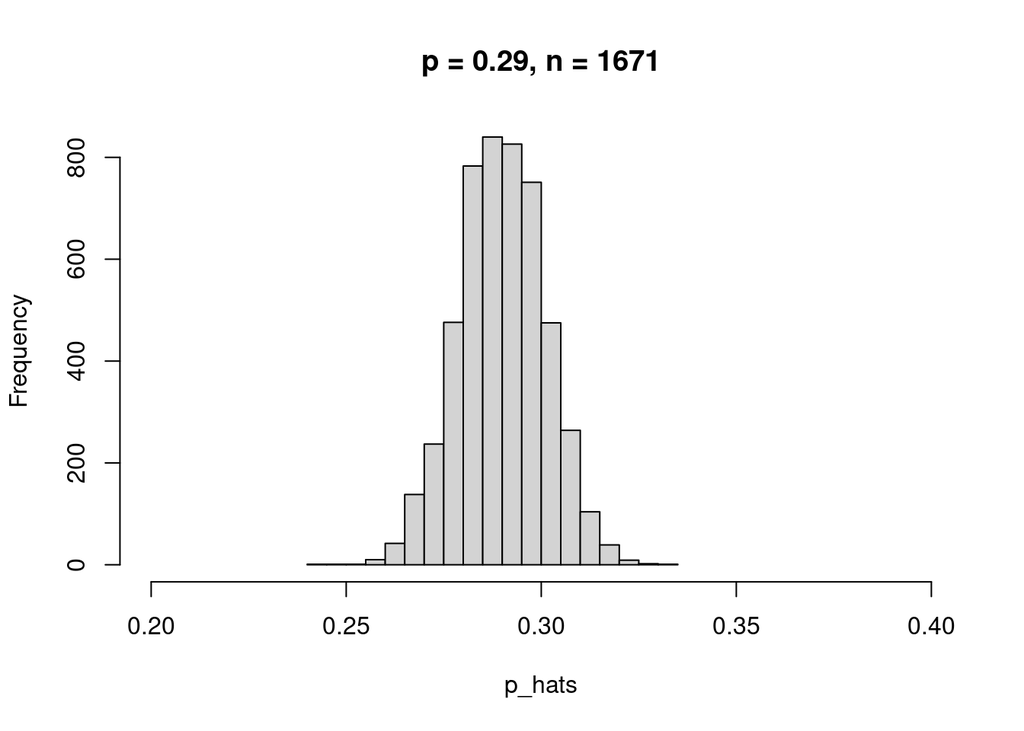

```r
# Set p and n, make empty vector to hold p_hat results for 5000 simulations
p <- 0.29
n <- 1671
p_hats <- rep(NA, 5000)
# Run 5000 simulations
for(i in 1:5000){
  samp <- sample(c("atheist", "non_atheist"), n, replace = TRUE, prob = c(p, 1-p))
  p_hats[i] <- sum(samp == "atheist")/n
}
# Plot using base R
hist(p_hats, main="p = 0.29, n = 1671", xlim=c(0.20, 0.40))
```

Aside – we’ve used base R plotting above, but we could do the same thing with ggplot:

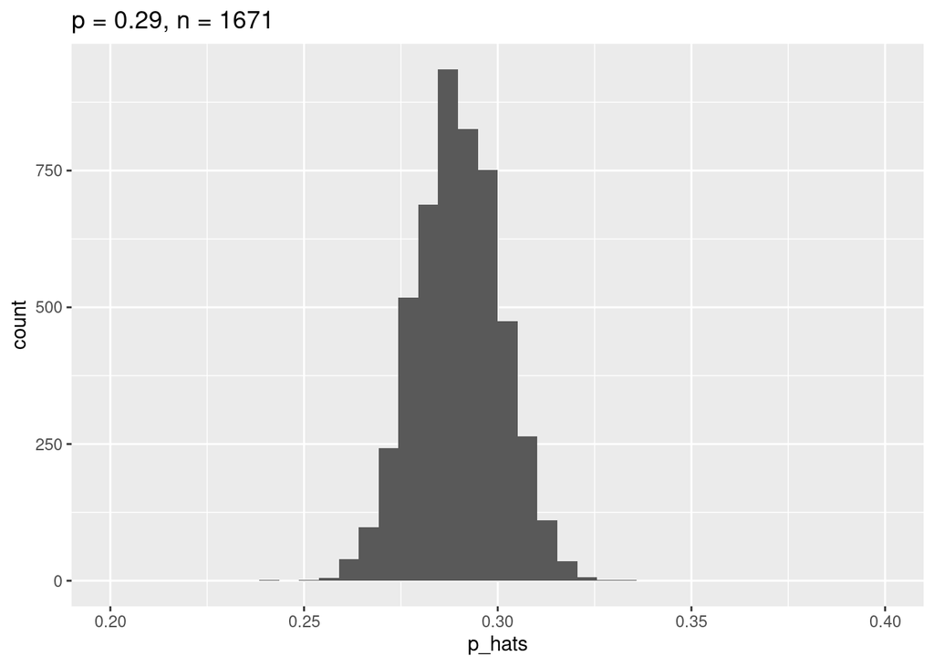

```r
# Turn into data frame to use ggplot()
df <- data.frame(p_hats = p_hats)
# Make histogram of all p_hats from 5000 simulations
ggplot(df, aes(x=p_hats)) +      # tell ggplot what data frame and data to look at
  geom_histogram(bins=40) +      # tell ggplot what type of plot we want
  ggtitle("p = 0.29, n = 1671") + # add title
  xlim(0.20, 0.40)  # set x limit
```

The commands in the simulation code build up the sampling distribution of $\hat{p}$ using a `for` loop. You can read the sampling procedure for the first line of code inside the `for` loop as, “take a sample of size $n$ with replacement from the choices of atheist and non-atheist with probabilities $p$ and $1 - p$, respectively.” The second line in the loop says, “calculate the proportion of atheists in this sample and record this value.” The loop allows us to repeat this process 5,000 times to build a good representation of the sampling distribution.

#### Exercise 6 (10 points)

**Describe the sampling distribution of sample proportions at $n = 1671$ and $p = 0.29$. Be sure to note the center, spread, and shape. *Hint:* Remember that R has functions such as `mean` to calculate summary statistics.**

#### Exercise 7 (15 points)

**Now calculate confidence intervals for the proportion of atheists in Ghana and Korea, Rep (South) in 2012, as well as their associated margins of error. How do these compare to the confidence interval for the proportion of atheists in France in 2012? Do both of these satisfy all our necessary conditions for making inference?**

## More Exercises

Remember to use the `inference` function when finding CIs. As always, write out the hypotheses for any tests you conduct and outline the status of the conditions for inference.

#### Exercise 8 (15 points)

**Calculate a confidence interval for the proportion of atheists in 2012 in another countries of your choice, and report the associated margins of error as in questions 4 and 5. Be sure to note whether the conditions for inference are met. Specifically, create a new data set for the country first, and then use this data set in the `inference` function to construct the confidence interval.**

As has been alluded to, Table 4 in the report shows values for atheism in various countries as found from similar surveys in 2005 and 2012. For smaller changes from 2005 to 2012, it’s not readily apparent whether that change is due to random chance or due to an underlying change in the proportion of atheists in the population. Let’s consider Korea, Rep (South).

#### Exercise 9 (10 points)

**Is there convincing evidence that Korea, Rep (South) has seen a change in its atheism index between 2005 and 2012? That is, does the 95% confidence interval of the difference in proportions of atheism include zero? *Hint:* Filter all Korea, Rep (South) data in the atheism dataset into a new dataset, and when you run inference on it, add an x= factor(year) argument.**

## Acknowledgments

This lab was adapted from Professor Kelly Moran’s [lab 5](https://kelrenmor.github.io/STA101-002/labs/lab5/lab5) for the purposes of Professor Smith’s Stat 101 class during Summer Session II. It was further adapted from Meredith Brown’s adaptation thereof for use in Professor Smith’s STA 101 class during Fall 2020.